# Week6HW

Brandon Croarkin

May 19, 2018

## Week 6 HW Assignment:

### Air Quality Analysis

```r
#load libraries
library(ggplot2)
library(gridExtra)
library(reshape2)
```

#### Step 1: Load the data

We will use the airquality data set, which you should already have as part of your R installation.

```r
df <- airquality
```

```r
head(df)
```

```
##   Ozone Solar.R Wind Temp Month Day
## 1    41     190  7.4   67     5   1
## 2    36     118  8.0   72     5   2
## 3    12     149 12.6   74     5   3
## 4    18     313 11.5   62     5   4
## 5    NA      NA 14.3   56     5   5
## 6    28      NA 14.9   66     5   6
```

#### Step 2: Clean the data

After you load the data, there will be some NAs in the data. You need to figure out what to do about those nasty NAs.

```r
nrow(df)
```

```
## [1] 153
```

```r
sum(complete.cases(df))
```

```
## [1] 111
```

```r
sum(complete.cases(df))/nrow(df)
```

```
## [1] 0.7254902
```

72.5% of our dataset is complete. I think that is enough to justify removing the rows with NA values.

```r
df_clean <- df[complete.cases(df),]
head(df_clean)
```

```
##   Ozone Solar.R Wind Temp Month Day
## 1    41     190  7.4   67     5   1
## 2    36     118  8.0   72     5   2
## 3    12     149 12.6   74     5   3
## 4    18     313 11.5   62     5   4
## 7    23     299  8.6   65     5   7
## 8    19      99 13.8   59     5   8
```

```r
all(is.na(df_clean))
```

```
## [1] FALSE
```

Can see that our data set is now clean!

#### Step 3: Understand the data distribution

Create the following visualizations using ggplot: . Histograms for each of the variables  
. Boxplot for Ozone . Boxplot for wind values (round the wind to get a good number of “buckets”)

```r
colnames(df_clean)
```

```
## [1] "Ozone"   "Solar.R" "Wind"    "Temp"    "Month"   "Day"
```

Ozone histogram

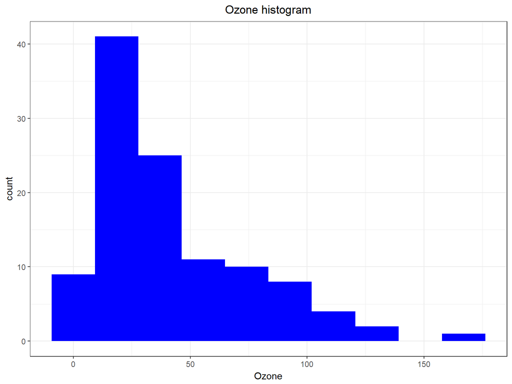

```r
ggplot(df_clean, aes(x=Ozone))+geom_histogram(bins=10,fill="blue")+theme_bw() + ggtitle("Ozone histogram") + theme(plot.title = element_text(hjust=.5))
```

Solar histogram

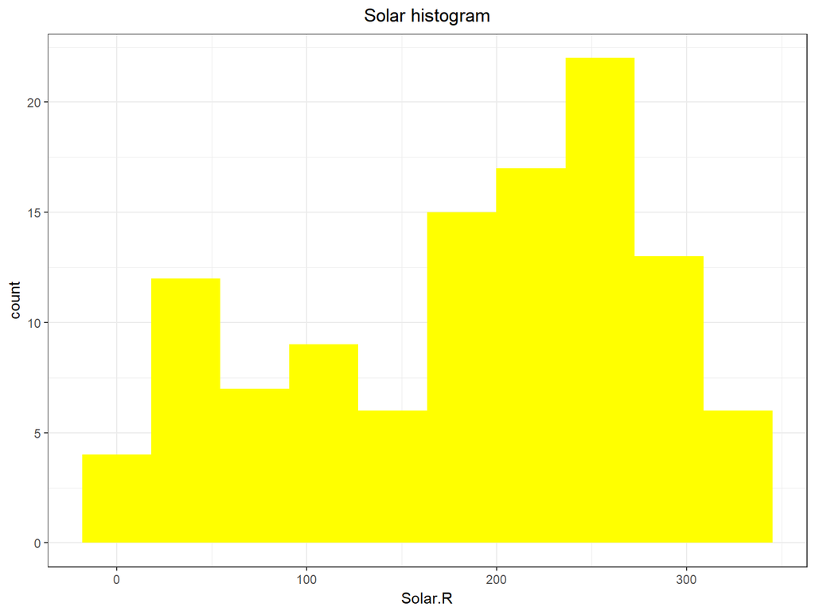

```r
ggplot(df_clean, aes(x=Solar.R))+geom_histogram(bins=10,fill="yellow")+theme_bw()+ ggtitle("Solar histogram") + theme(plot.title = element_text(hjust=.5))
```

Wind histogram

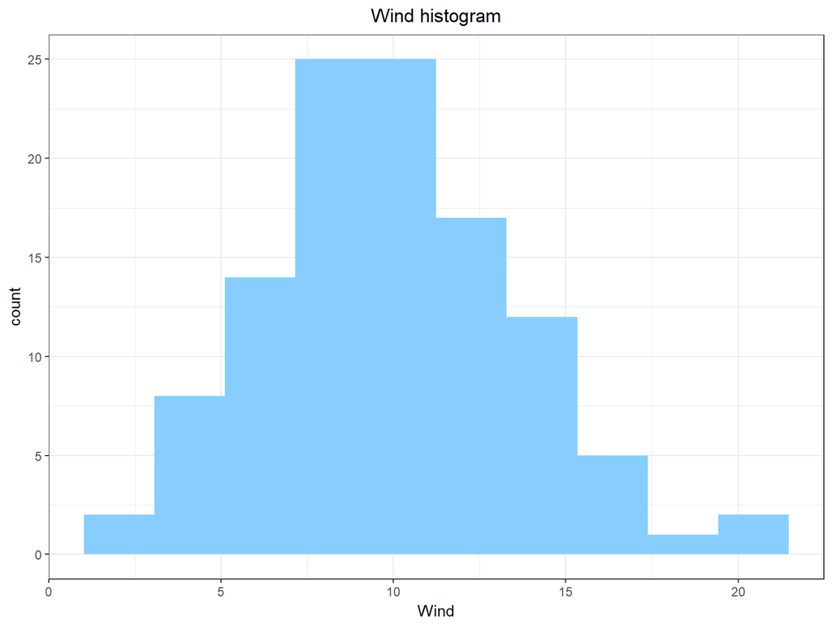

```r
ggplot(df_clean, aes(x=Wind))+geom_histogram(bins=10,fill="skyblue1")+theme_bw() + ggtitle("Wind histogram") + theme(plot.title = element_text(hjust=.5))
```

Temp histogram

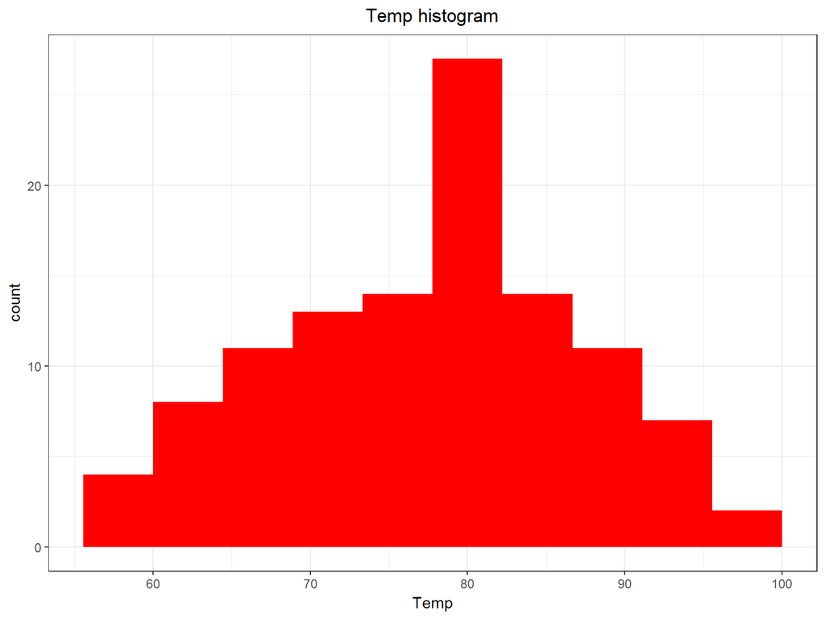

```r
ggplot(df_clean, aes(x=Temp))+geom_histogram(bins=10,fill="red")+theme_bw()+ ggtitle("Temp histogram") + theme(plot.title = element_text(hjust=.5))
```

Boxplot for Ozone

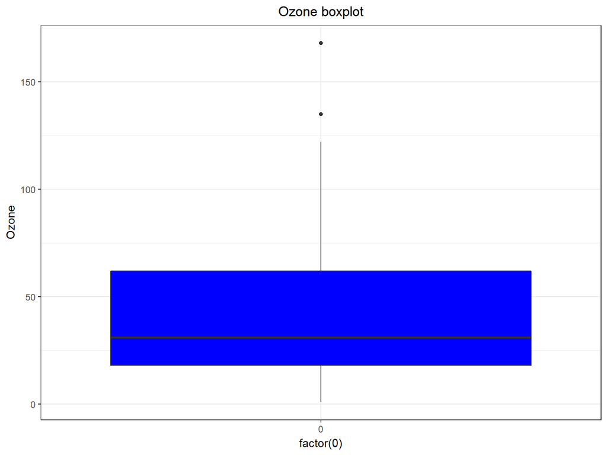

```r
ggplot(df_clean, aes(x=factor(0), y=Ozone))+geom_boxplot(fill="blue")+theme_bw() + ggtitle("Ozone boxplot") + theme(plot.title = element_text(hjust=.5))
```

Boxplot for wind values

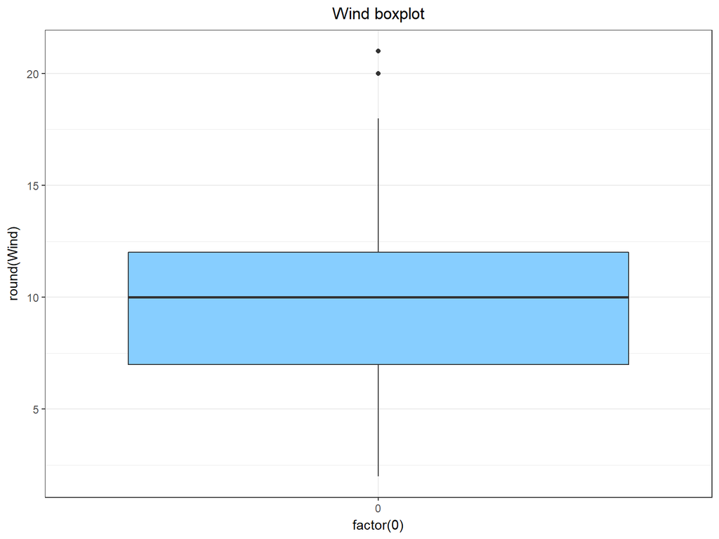

```r
ggplot(df_clean, aes(x=factor(0), y=round(Wind)))+geom_boxplot(fill="skyblue1")+theme_bw() + ggtitle("Wind boxplot") + theme(plot.title = element_text(hjust=.5))
```

#### Step 3: Explore how the data changes over time

First, make sure to create appropriate dates (this data was from 1973).

```r
df_clean$Year <- 1973
```

```r
df_clean$Date <- as.Date(with(df_clean,paste(Year,Month,Day,sep="-")), "%Y-%m-%d")
str(df_clean)
```

```
## 'data.frame':    111 obs. of  8 variables:
##  $ Ozone  : int  41 36 12 18 23 19 8 16 11 14 ...
##  $ Solar.R: int  190 118 149 313 299 99 19 256 290 274 ...
##  $ Wind   : num  7.4 8 12.6 11.5 8.6 13.8 20.1 9.7 9.2 10.9 ...
##  $ Temp   : int  67 72 74 62 65 59 61 69 66 68 ...
##  $ Month  : int  5 5 5 5 5 5 5 5 5 5 ...
##  $ Day    : int  1 2 3 4 7 8 9 12 13 14 ...
##  $ Year   : num  1973 1973 1973 1973 1973 ...
##  $ Date   : Date, format: "1973-05-01" "1973-05-02" ...
```

Then create line charts for ozone, temp, wind and solar.R (one line chart for each, and then one chart with 4 lines, each having a different color). Create these visualizations using ggplot.

Note that for the chart with 4 lines, you need to think about how to effectively use the yaxis.

Ozone line chart

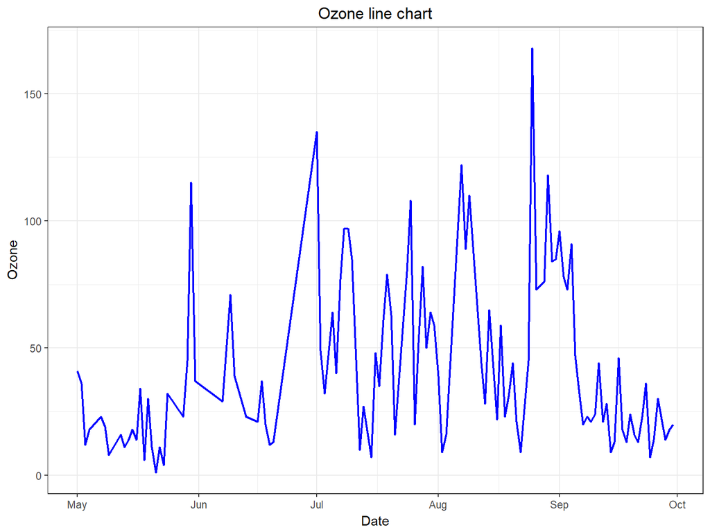

```r
ggplot(df_clean, aes(x=Date, y=Ozone))+geom_line(color="blue",size=.75)+theme_bw()+ ggtitle("Ozone line chart") + theme(plot.title = element_text(hjust=.5))
```

Temp line chart

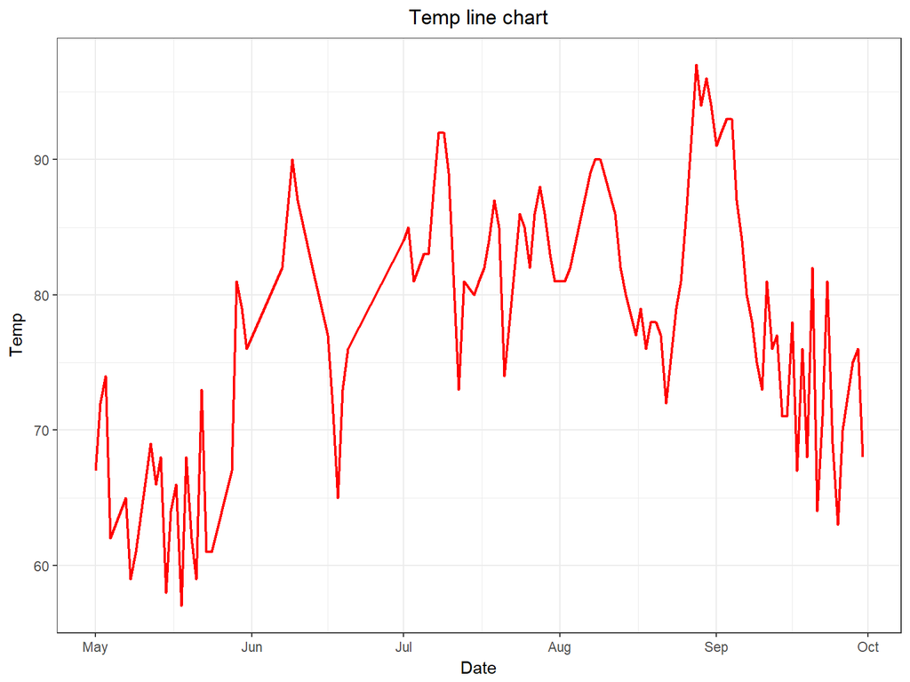

```r
ggplot(df_clean, aes(x=Date, y=Temp))+geom_line(color="red",size=.75)+theme_bw() + ggtitle("Temp line chart") + theme(plot.title = element_text(hjust=.5))
```

Wind line chart

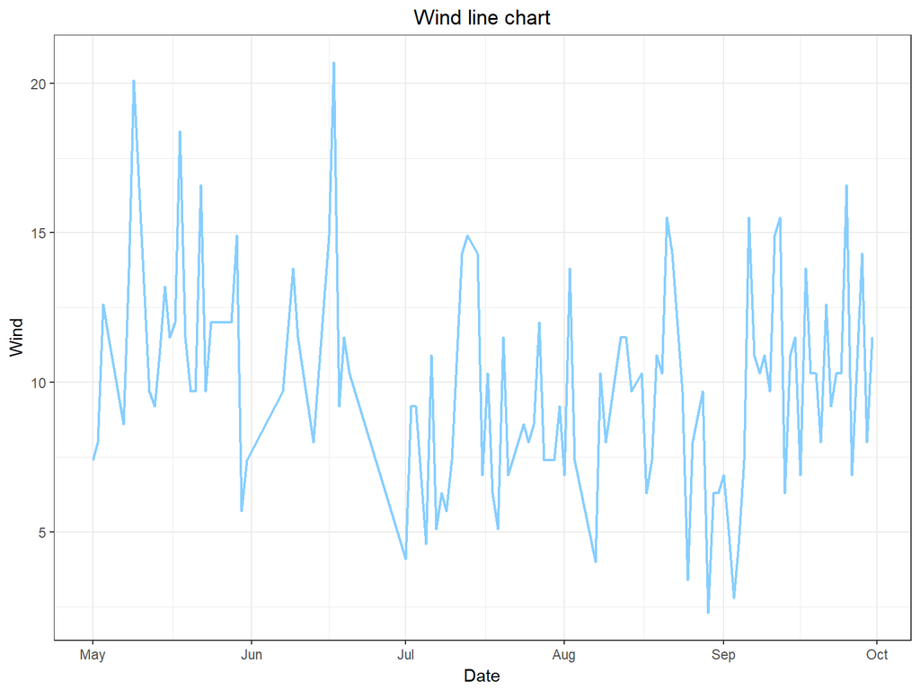

```r
ggplot(df_clean, aes(x=Date, y=Wind))+geom_line(color="skyblue1",size=.75)+theme_bw() + ggtitle("Wind line chart") + theme(plot.title = element_text(hjust=.5))
```

Solar.R line chart

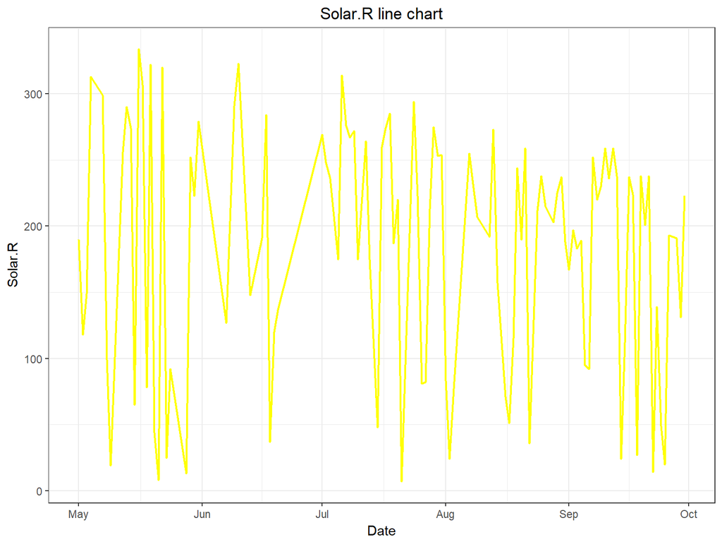

```r
ggplot(df_clean, aes(x=Date, y=Solar.R))+geom_line(color="yellow",size=.75)+theme_bw() + ggtitle("Solar.R line chart") + theme(plot.title = element_text(hjust=.5))
```

Combined line chart

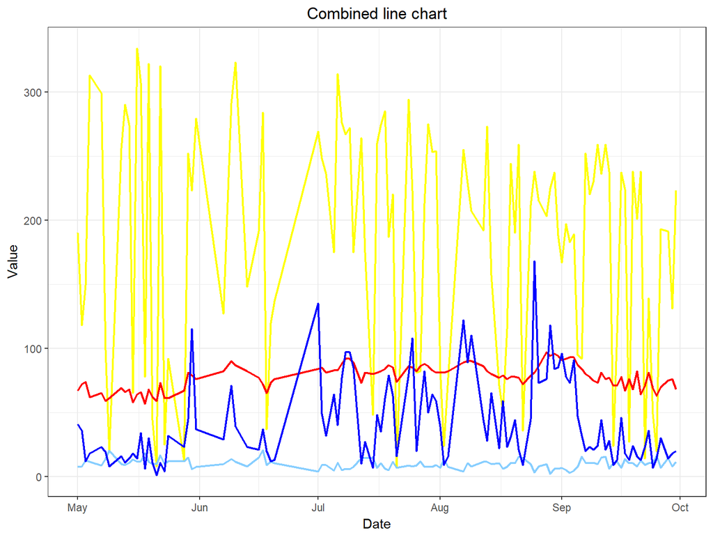

```r
ggplot(df_clean) +
  geom_line(aes(x=Date, y=Solar.R), color="yellow",size=.75,label="Solar.R") +
  geom_line(aes(x=Date, y=Temp), color="red",size=.75) +
  geom_line(aes(x=Date, y=Wind), color="skyblue1",size=.75) +
  geom_line(aes(x=Date, y=Ozone), color="blue",size=.75)+theme_bw() +
  ggtitle("Combined line chart") +
  ylab("Value") +
  theme(plot.title = element_text(hjust=.5))
```

Combined line chart (version 2)

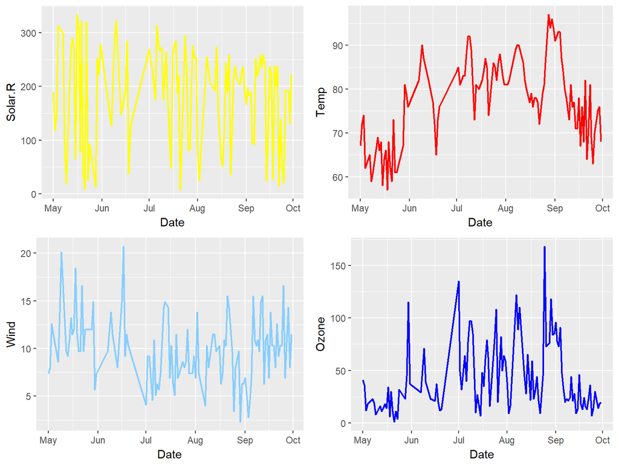

```r
p1 <- ggplot(df_clean) + geom_line(aes(x=Date, y=Solar.R), color="yellow",size=.75)
p2 <- ggplot(df_clean) + geom_line(aes(x=Date, y=Temp), color="red",size=.75)
p3 <- ggplot(df_clean) + geom_line(aes(x=Date, y=Wind), color="skyblue1",size=.75)
p4 <- ggplot(df_clean) + geom_line(aes(x=Date, y=Ozone), color="blue",size=.75)
grid.arrange(p1, p2, p3, p4, ncol=2)
```

#### Step 4: Look at all the data via a Heatmap

Create a heatmap, with each day along the x-axis and ozone, temp, wind and solar.r along the y-axis, and days as rows along the y-axis. Great the heatmap using geom_tile (this defines the ggplot geometry to be ‘tiles’ as opposed to ‘lines’ and the other geometry we have previously used).

Note that you need to figure out how to show the relative change equally across all the variables.

```r
#scale data
df_clean2 <- df_clean
df_clean2$Ozone <- scale(df_clean2$Ozone)
df_clean2$Temp <- scale(df_clean2$Temp)
df_clean2$Solar.R <- scale(df_clean2$Solar.R)
df_clean2$Wind <- scale(df_clean2$Wind)
head(df_clean2)
```

```
##         Ozone     Solar.R       Wind       Temp Month Day Year       Date
## 1 -0.03302982  0.05702761 -0.7138405 -1.1325108     5   1 1973 1973-05-01
## 2 -0.18328840 -0.73285918 -0.5451928 -0.6078501     5   2 1973 1973-05-02
## 3 -0.90452961 -0.39276904  0.7477726 -0.3979858     5   3 1973 1973-05-03
## 4 -0.72421931  1.40641756  0.4385852 -1.6571715     5   4 1973 1973-05-04
## 7 -0.57396073  1.25282846 -0.3765451 -1.3423751     5   7 1973 1973-05-07
## 8 -0.69416759 -0.94130153  1.0850679 -1.9719679     5   8 1973 1973-05-08
```

```r
#melt dataframe
df_clean2 <- melt(df_clean2,id.vars = "Day",measure.vars = c("Temp","Wind","Solar.R","Ozone"))
head(df_clean2)
```

```
##   Day variable      value
## 1   1     Temp -1.1325108
## 2   2     Temp -0.6078501
## 3   3     Temp -0.3979858
## 4   4     Temp -1.6571715
## 5   7     Temp -1.3423751
## 6   8     Temp -1.9719679
```

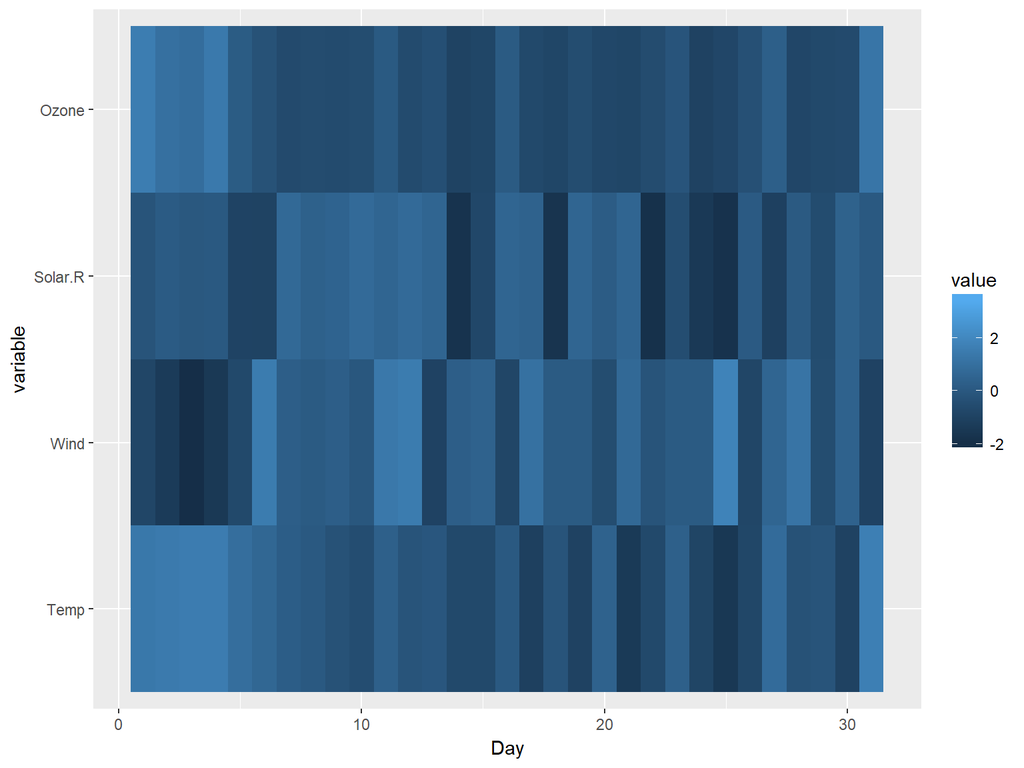

```r
#make heatmap
ggplot(df_clean2,aes(Day,variable))+geom_tile(aes(fill=value))
```

#### Step 5: Look at all the data via a scatter chart

Create a scatter chart (using ggplot geom_point), with the x-axis representing the wind, the y-axis representing the temperature, the size of each dot representing the ozone and the color representing the solar.R

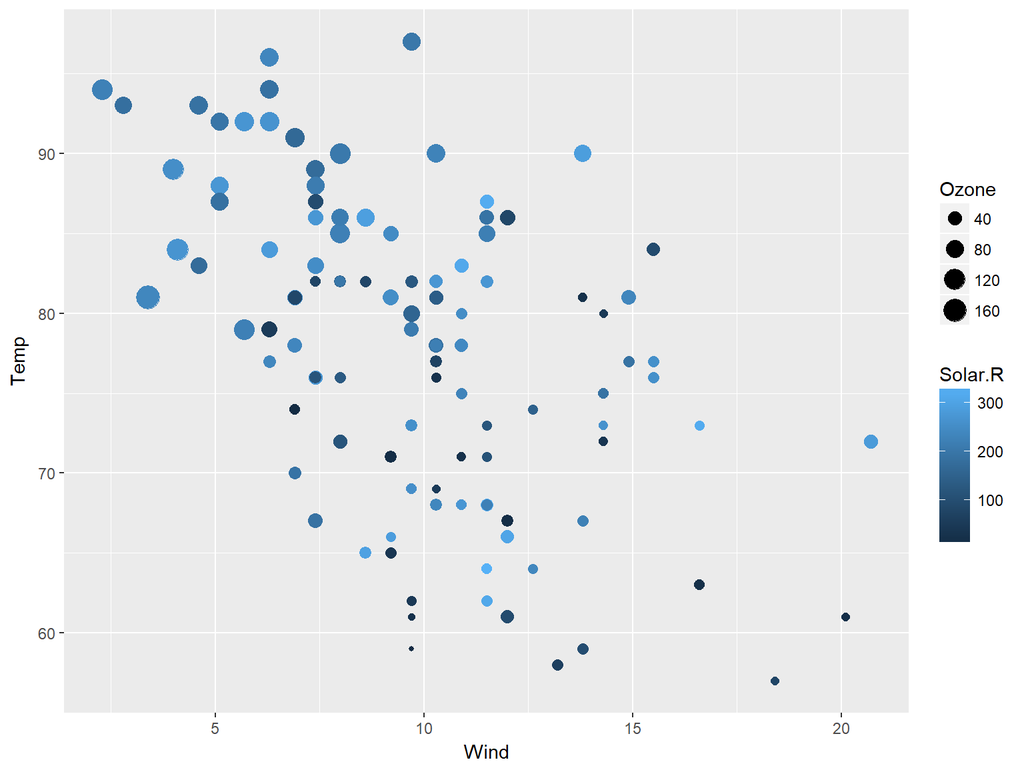

```r
ggplot(df_clean, aes(x=Wind,y=Temp,size = Ozone, color = Solar.R)) + geom_point()
```

#### Step 6: Final Analysis

. Do you see any patterns after exploring the data?

There was an expected trend that it was warmer during summer months. High wind seems to be associated with lower temperatures. Higher ozone levels can also be seen with higher temperatures.

. What was the most useful visualization?

The final scatter was the most useful visualization for me. It was able to put the most information in one easy to read chart.